# Session 2: Tidyverse

## What is Tidyverse?

The tidyverse is an opinionated collection of R packages designed for data science. All packages share an underlying philosophy and are implemented in a similar way.

[figure not shown]

## Package: dplyr

Important verbs/functions that you learned from this package are:

### 1. filter

Take a look at the arithmetic and logical operators here

```r
library(gapminder)
library(dplyr)

gapminder %>% filter(year=='2007' & continent=="Asia")
```

```
## # A tibble: 33 x 6
##             country continent  year lifeExp        pop  gdpPercap
##              <fctr>    <fctr> <int>   <dbl>      <int>      <dbl>
##  1      Afghanistan      Asia  2007  43.828   31889923   974.5803
##  2          Bahrain      Asia  2007  75.635     708573 29796.0483
##  3       Bangladesh      Asia  2007  64.062  150448339  1391.2538
##  4         Cambodia      Asia  2007  59.723   14131858  1713.7787
##  5            China      Asia  2007  72.961 1318683096  4959.1149
##  6 Hong Kong, China      Asia  2007  82.208    6980412 39724.9787
##  7            India      Asia  2007  64.698 1110396331  2452.2104
##  8        Indonesia      Asia  2007  70.650  223547000  3540.6516
##  9             Iran      Asia  2007  70.964   69453570 11605.7145
## 10             Iraq      Asia  2007  59.545   27499638  4471.0619
## # ... with 23 more rows
```

### 2. arrange

```r
gapminder %>%
  filter(year=='2007' & continent=="Asia") %>%
  arrange(desc(lifeExp))
```

```
## # A tibble: 33 x 6
##             country continent  year lifeExp       pop gdpPercap
##              <fctr>    <fctr> <int>   <dbl>     <int>     <dbl>
##  1            Japan      Asia  2007  82.603 127467972 31656.068
##  2 Hong Kong, China      Asia  2007  82.208   6980412 39724.979
##  3           Israel      Asia  2007  80.745   6426679 25523.277
##  4        Singapore      Asia  2007  79.972   4553009 47143.180
##  5      Korea, Rep.      Asia  2007  78.623  49044790 23348.140
##  6           Taiwan      Asia  2007  78.400  23174294 28718.277
##  7           Kuwait      Asia  2007  77.588   2505559 47306.990
##  8             Oman      Asia  2007  75.640   3204897 22316.193
##  9          Bahrain      Asia  2007  75.635    708573 29796.048
## 10          Vietnam      Asia  2007  74.249  85262356  2441.576
## # ... with 23 more rows
```

### 3. summarize & group_by

```r
gapminder %>%
  filter(year=='2007' & continent=="Asia") %>%
  arrange(desc(lifeExp)) %>%
  group_by(country) %>%
  summarize(median=mean(lifeExp))
```

```
## # A tibble: 33 x 2
##             country median
##              <fctr>  <dbl>
##  1      Afghanistan 43.828
##  2          Bahrain 75.635
##  3       Bangladesh 64.062
##  4         Cambodia 59.723
##  5            China 72.961
##  6 Hong Kong, China 82.208
##  7            India 64.698
##  8        Indonesia 70.650
##  9             Iran 70.964
## 10             Iraq 59.545
## # ... with 23 more rows
```

### 4. Mutate

```r
gapminder_asia<-gapminder %>%
  filter(year=='2007' & continent=="Asia") %>%
  arrange(desc(lifeExp)) %>%
  group_by(country,pop,gdpPercap) %>%
  summarize(median_life=mean(lifeExp)) %>%
  mutate(med_life_months=median_life*12)
```

## Package: ggplot2

1. ggplot
2. aes(x,y,color,size,label)
3. geom_point,geom_bar, geom_hist etc

### Example

#### Simple Scatter plot

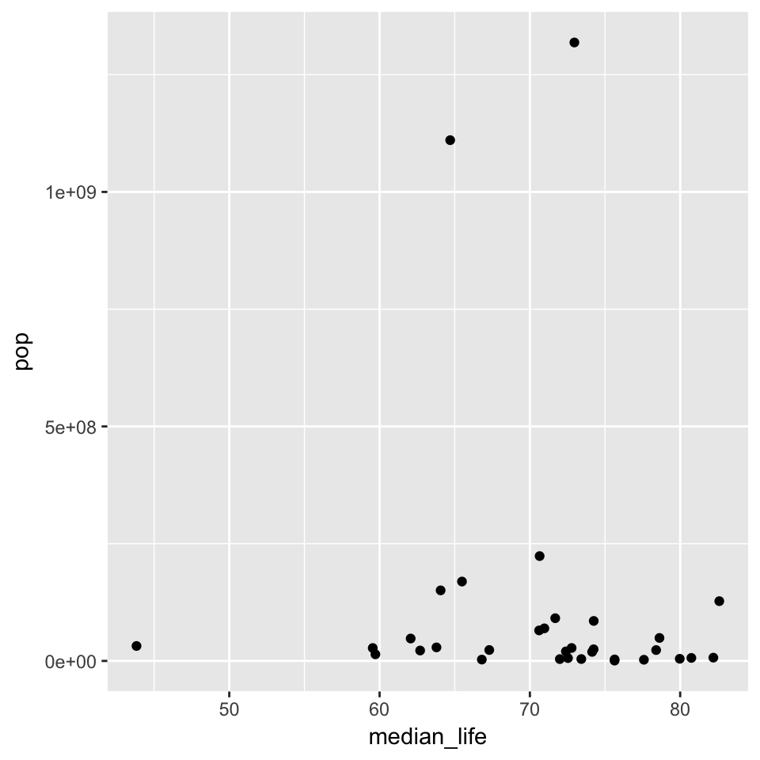

```r
library(ggplot2)
ggplot(gapminder_asia,aes(x=median_life,y=pop)) + geom_point()
```

#### Scatter plot with gdp as point size

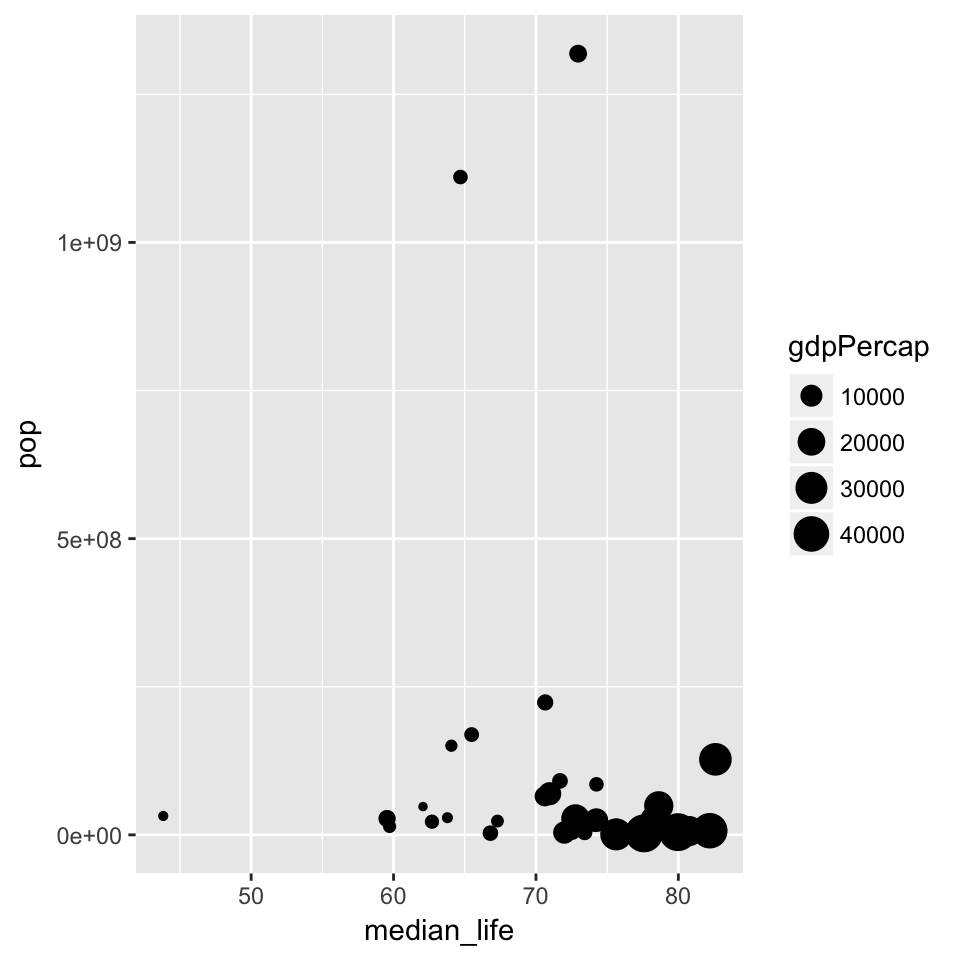

```r
ggplot(gapminder_asia,aes(x=median_life,y=pop,size=gdpPercap)) + geom_point()
```

#### Add labels

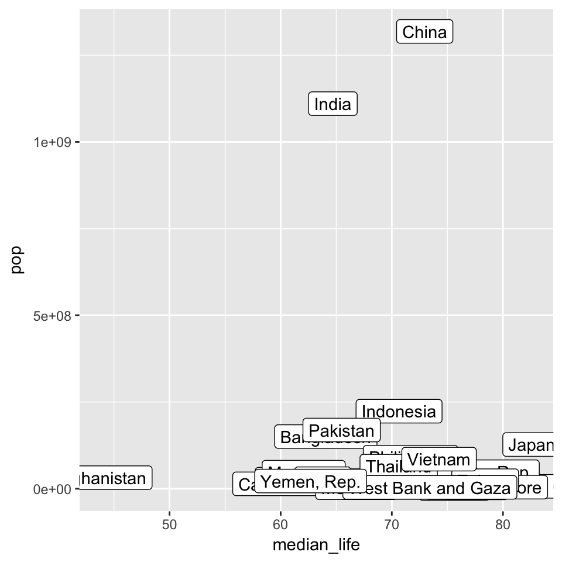

```r
ggplot(gapminder_asia,aes(x=median_life,y=pop, label=country)) + geom_point() +geom_label()
```

#### Full example of dplyr and ggplot together

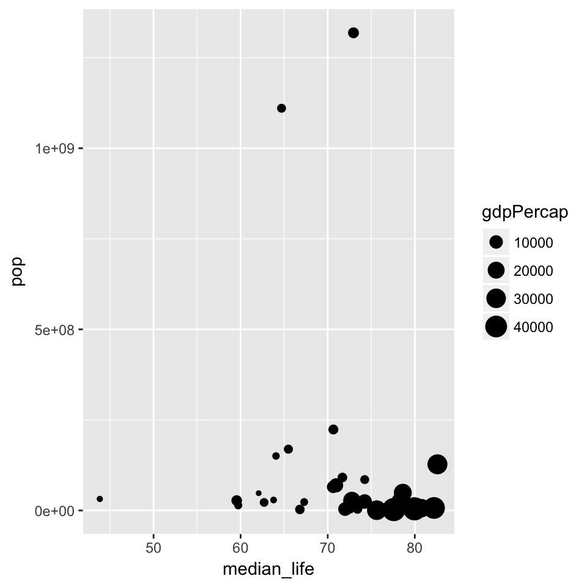

```r
library(ggplot2)

gapminder %>%
  filter(year=='2007' & continent=="Asia") %>%
  arrange(desc(lifeExp)) %>%
  group_by(country,pop,gdpPercap) %>%
  summarize(median_life=mean(lifeExp)) %>%
  mutate(med_life_months=median_life*12) %>%
  ggplot(aes(x=median_life,y=pop,size=gdpPercap)) + geom_point()
```

# Packages to learn

## Package: readr

The goal of readr is to provide a fast and friendly way to read rectangular data (like csv, tsv, and fwf). It is designed to flexibly parse many types of data found in the wild, while still cleanly failing when data unexpectedly changes.

Please look at this link to get to know the functions in readr http://r4ds.had.co.nz/data-import.html

Download the iris.csv [from here](https://wcmcbioinformatics.github.io/Rbootcamp2018/code/data/iris.csv)

Before you proceed, please think about the directory structure here

### Example

```r
#load library
library(readr)

iris<-read_csv("data/iris.csv")

# View a snapshot of the data
head(iris)
```

```
## # A tibble: 6 x 5
##   Sepal.Length Sepal.Width Petal.Length Petal.Width Species
##          <dbl>       <dbl>        <dbl>       <dbl>   <chr>
## 1          5.1         3.5          1.4         0.2  setosa
## 2          4.9         3.0          1.4         0.2  setosa
## 3          4.7         3.2          1.3         0.2  setosa
## 4          4.6         3.1          1.5         0.2  setosa
## 5          5.0         3.6          1.4         0.2  setosa
## 6          5.4         3.9          1.7         0.4  setosa
```

```r
#check dimensions
dim(iris)
```

```
## [1] 150   5
```

## Practice exercise

### Question 1: Make some plots to understand the dataset

1. Make a plot scatter plot of Sepal.Length on x axis and Petal.Length on y axis
2. Separate the above plot by species. (Hint: use facet_wrap)
3. Make a histogram of Petal.Length and color them by Species (Hint: You can use the color aesthetic or fill aesthetic)

#### Answer 1

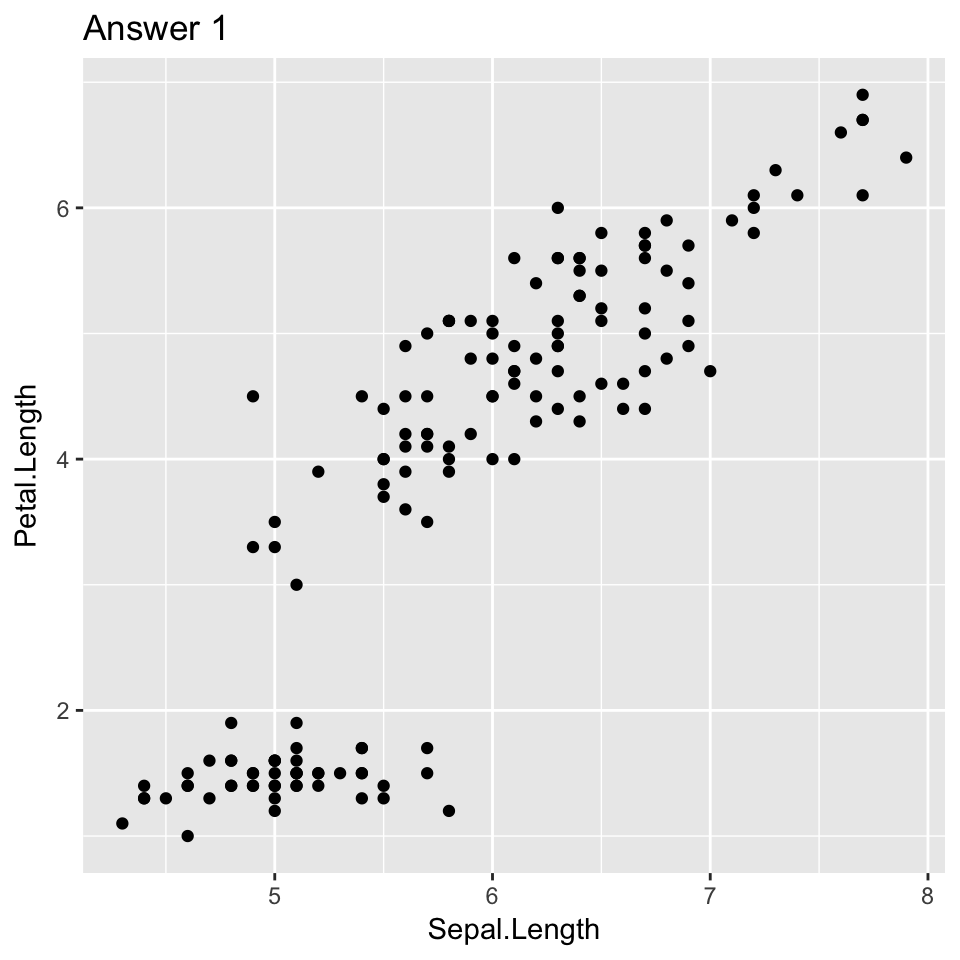

#### Answer 2

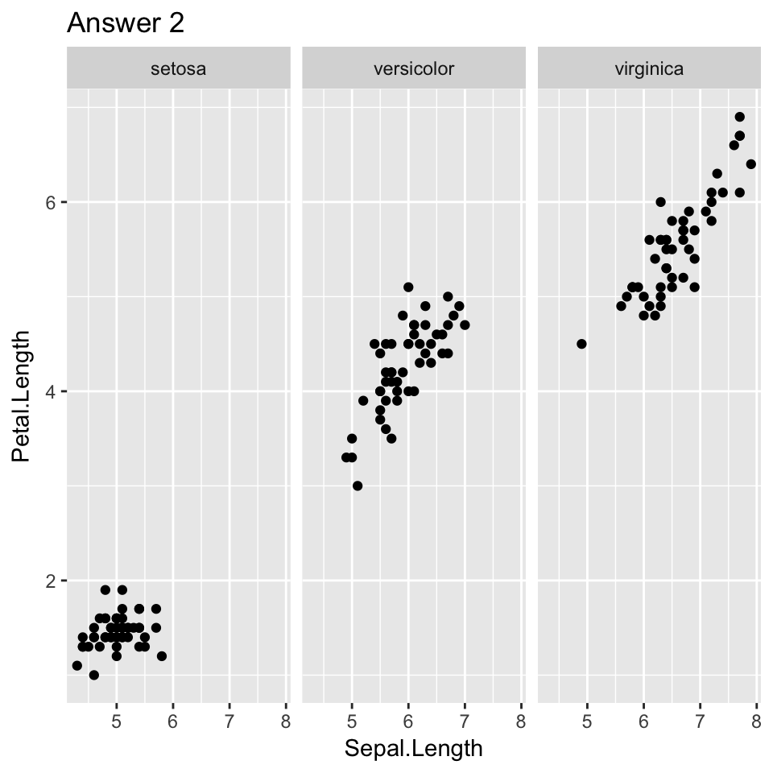

#### Answer 3

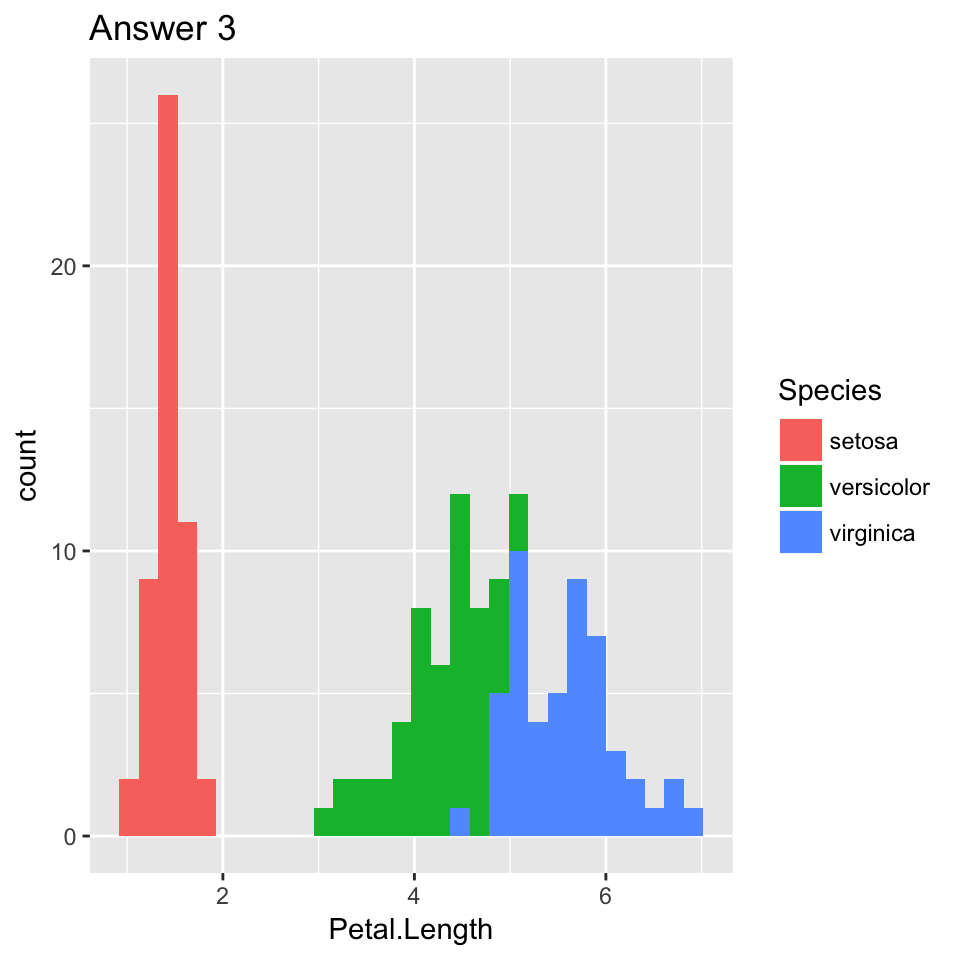

### Question 2: Lets use functions from dplyr package

1. Keep all rows with Sepal.Length > 5 and save it in a variable.
2. Make a plot using this data of petal length on x axis and petal width on y axis
3. Keep all rows with Sepal.Length > 5, group by Species and then calculate the median Petal Length
4. Make a simple column plot (geom_col) of median petal length for each species.

#### Answer 1 & 2

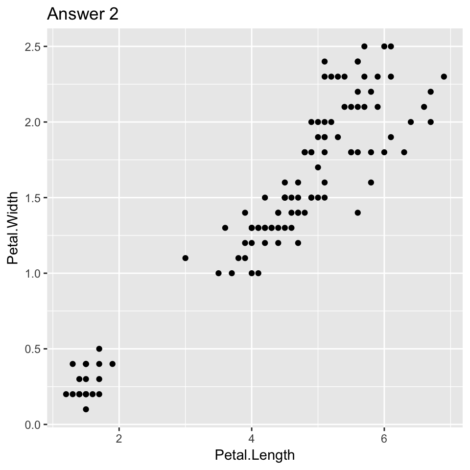

#### Answer 3 & 4

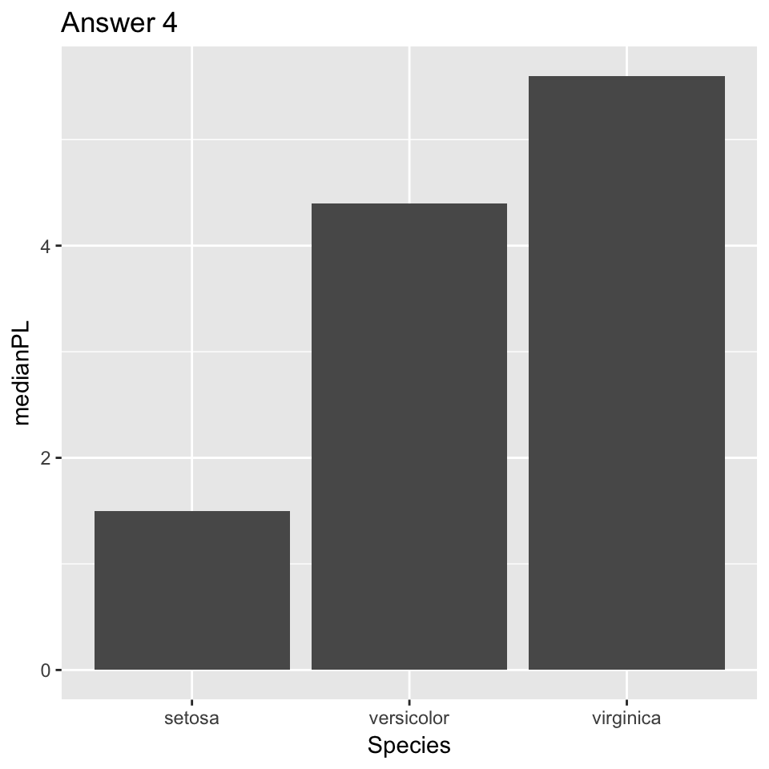

## Useful information

### Arithmetic Operators

| Operator | Description |
| --- | --- |
| + | addition |
| - | subtraction |
| * | multiplication |
| / | division |
| ^ or ** | exponentiation |
| x %% y | modulus (x mod y) 5%%2 is 1 |
| x %/% y | integer division 5%/%2 is 2 |

### Logical Operators

[output not shown]

## Directory Structure

Project_name

```
          |data

          |code

          |results

          |plots
```

## Tidyverse cheatsheet

https://s3.amazonaws.com/assets.datacamp.com/blog_assets/Tidyverse+Cheat+Sheet.pdf